# CPLN 675: Homework 3

Mimi Tran & Javier Fernandez

April 3, 2024

# Introduction

Climate change impacts such as sea level rise and more severe and frequent weather events like heavy rains exacerbate present flood threats. Identifying flood vulnerable areas and predicting where flooding may occur is integral to planning for a climate-changed future. The following report is a part of an effort to develop and test a predictive flood model:

We have been tasked with creating a model that predicts areas vulnerable to flooding. In order to do so, we chose an area where we already had recorded flood data: Calgary, Alberta (CAN). In addition, we needed to choose a comparable city to Calgary, one that could test our model. We chose Washington DC. Both Calgary and DC have large rivers running through the cities and are large population centers.

After choosing our cities, we came up with potential factors that might lead to flooding. Those factors are:

- Elevation
- Impervious Surfaces
- Parks
- Low Permeable Soils (e.g. clay)
- Waterbodies

For each factor, we came up with a hypothesis:

- Elevation: If an area has low elevation, it will most likely flood.
- Impervious Surfaces: If an area has or is made up of many impervious surfaces, it will most likely flood.
- Parks: If an area has or is made up of many green spaces, it will most likely not flood.
- Low Permeable Soils: If an area has or is made up of many low permeable soils, it will most likely flood.
- Waterbodies: If an area has or is made up of existing waterbodies, it will most likely flood.

Ultimately, the DC predictive model did not perform how we would have hoped; however, we found promising results in our Calgary model. This draws us to conclude that Washington DC may not have been a good fit as a comparison city. For example, while Calgary is far more inland and has a drier climate, DC is relatively close to the Chesapeake Bay and tends to be more humid. Other US cities that might have been more comparable to Calgary could have been Denver, CO, or Salt Lake City, UT.

# Maps of Variables

To begin our modeling process in R, we uploaded our Calgary fishnet and our predictive factors or “variables”: elevation, impervious surfaces, low permeable soils, parks, and waterbodies. A fishnet is a grid made up of squares–like a net–called “cells” overlaid on some geographic area. Fishnets have many uses, but our main purpose was to use the fishnet for spatial analysis and modeling.

The fishnet allows us to measure the presence or “how much” of a variable is found within a certain area or cell. By running zonal statistics for each variable in ArcGIS, we determined what was the best measure for each variable:

- Elevation: We decided to measure the lowest point of each cell, or the minimum value of elevation. We operated under the assumption that the lowest point of every cell is where most water within the cell will gather.
- Impervious Surfaces: If the mean count of “impervious surface” pixels withi na cell was equal to or exceeded 25% of a cell, then the cell possessed impervious surfaces.
- Low Permeable Soils: If the mean count of “low permeable soil” pixels within a cell was equal to or exceeded 25% of a cell, then the cell possessed low permeable soils.
- Parks: If the mean count of “park” pixels of within a cell was equal to or exceeded 25%, then the cell possessed a park.
- Waterbodies: If the mean count of “waterbodies” pixels of within a cell was equal to or exceeded 25%, then the cell possessed a waterbody.

Four of these maps are visualized in the next section.

## Impervious Surfaces

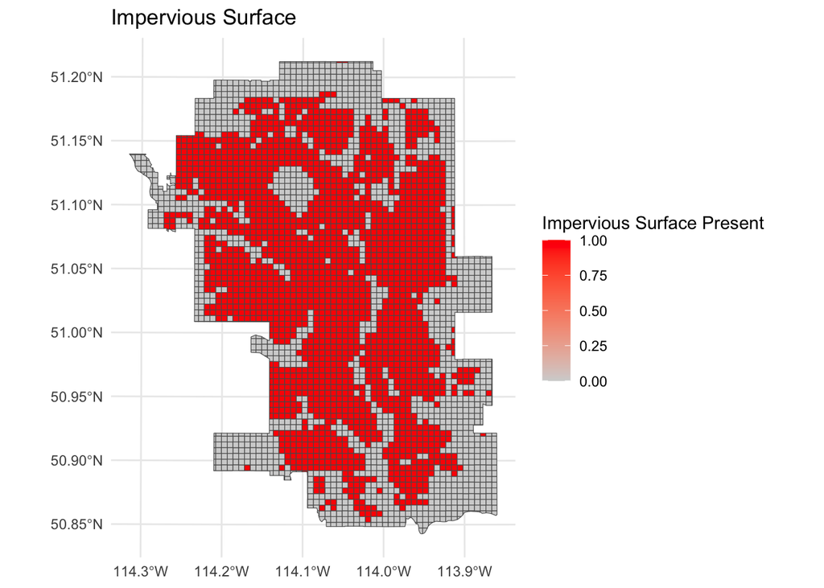

## Parks

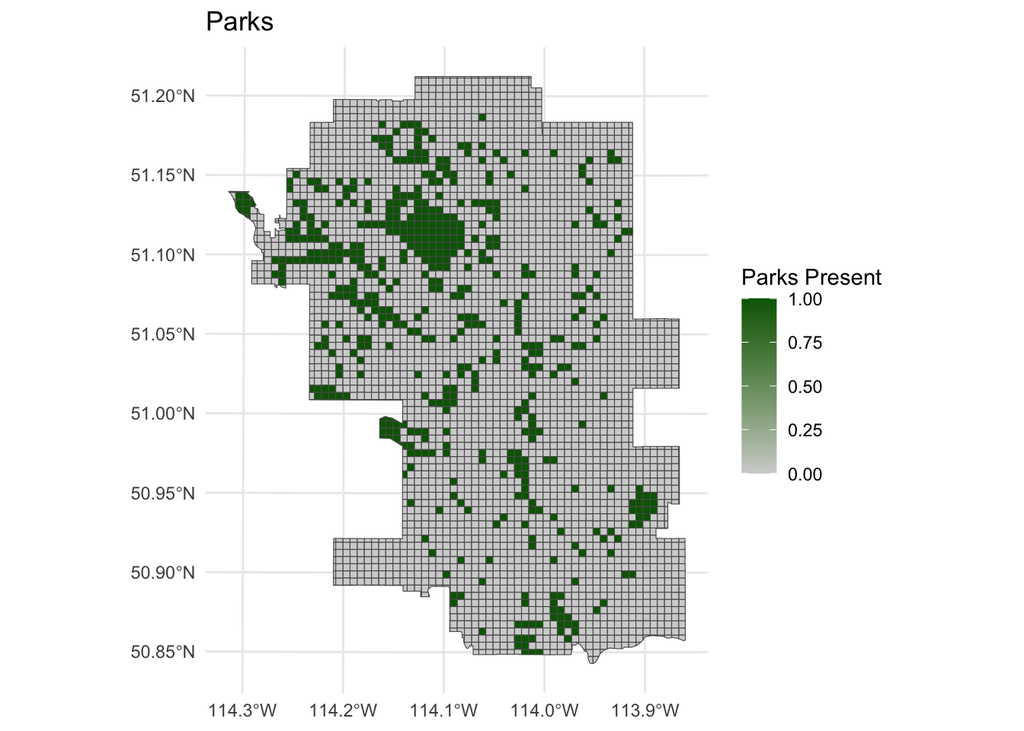

## Low Permeable Soils

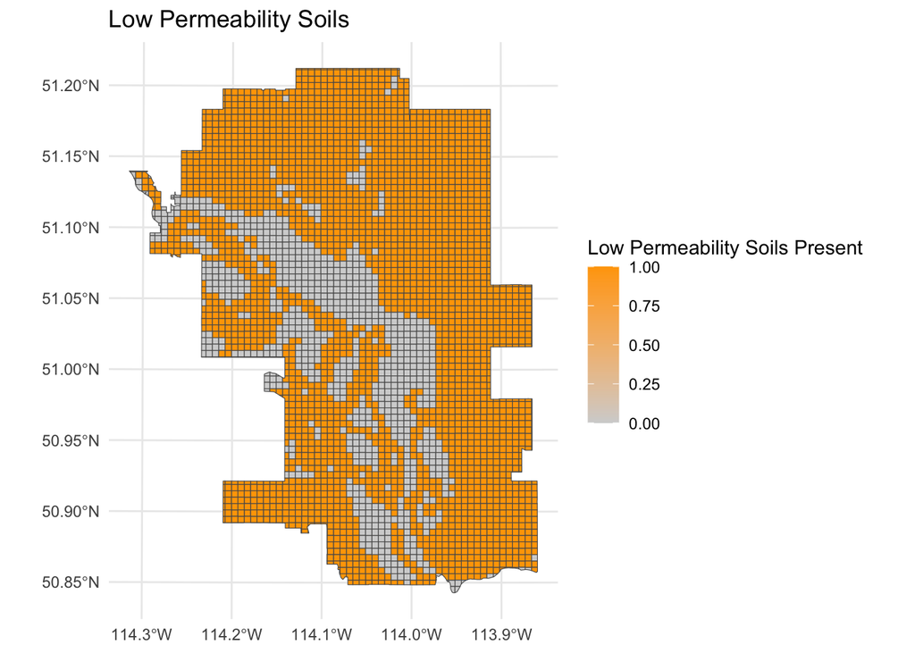

## Existing Waterbodies

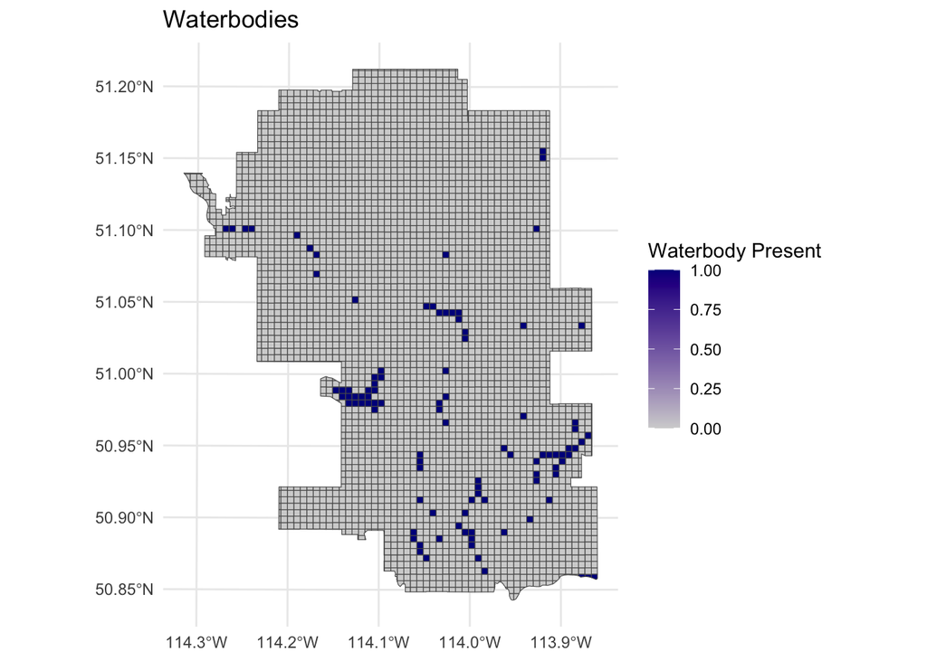

# Final Logistic Regression Model

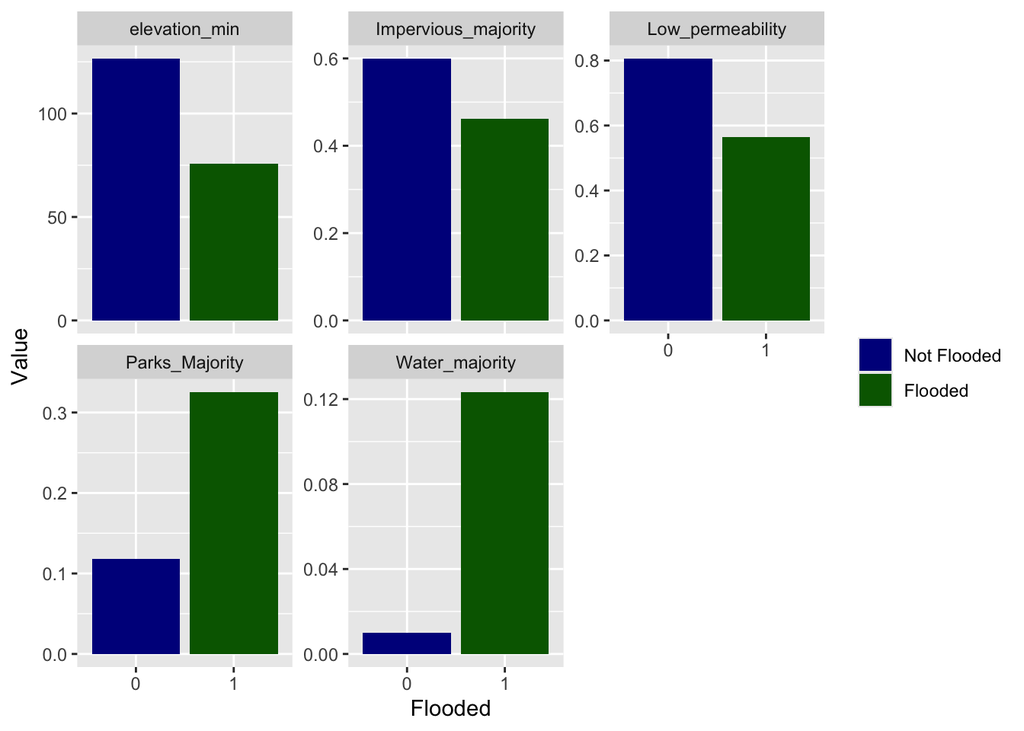

Our summary table may be telling us a positive story: what do we know about Calgary’s stormwater infrastructure? If Calgary has strong stormwater infrastructure, then this may explain why areas of low elevation and parks are flooded while areas with impervious surfaces and soils are not. For example, it is desireable green stormwater infrastructure practice to use parks as multi-use spaces: during heavy rains, parks can serve as stormwater holding basins and/or help absorb excess water.

Additionally, if Calgary’s stormwater infrastructure is effective, then water should be redirected away from urban areas. Stormwater infrastructure is often paired with city’s water systems, and many cities including Calgary utilize gravity systems, utilizing gravity to direct water flow “downwards” or towards areas of low elevation (often waterbodies or water treatment plants).

Although our summary table shows that our variables are not necessarily following our assumptions, they may be revealing an interesting story!

Call: glm(formula = Flooded ~ ., family = binomial(link = “logit”), data = floodTrain %>% as.data.frame() %>% dplyr::select(-geometry, -cell))

(Dispersion parameter for binomial family taken to be 1)

```
Null deviance: 2253.5  on 2498  degrees of freedom
```

Residual deviance: 1559.3 on 2493 degrees of freedom AIC: 1571.3

Number of Fisher Scoring iterations: 6

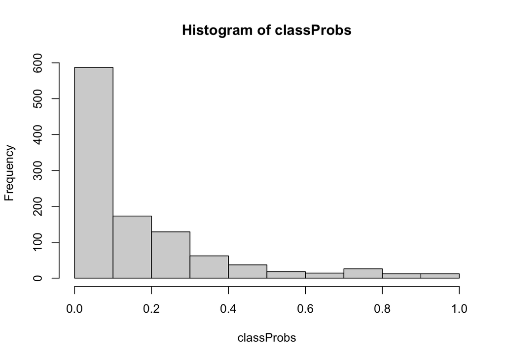

Confusion Matrix and Statistics

```
      Reference
```

```
           Accuracy : 0.8196
             95% CI : (0.7953, 0.8422)
No Information Rate : 0.8439
P-Value [Acc > NIR] : 0.986

              Kappa : 0.4283
```

Mcnemar’s Test P-Value : 8.485e-09

```
        Sensitivity : 0.6647
        Specificity : 0.8483
     Pos Pred Value : 0.4476
     Neg Pred Value : 0.9319
         Prevalence : 0.1561
     Detection Rate : 0.1037
```

Detection Prevalence : 0.2318  
Balanced Accuracy : 0.7565

```
   'Positive' Class : 1
```

We originally ran our confusion matrix with a 50% probability level; however, after observing that our model was more accurate given a 25% probability level, we changed the level that we wanted the model to consider a cell “flooded” to 25%.

According to the Confusion Matrix, our model runs at about an 82% accuracy rate and is best at predicting which cells are not flooded, but is less accurate at predicting which cells will flood.

This information is summed up in the sensitivity and specificity measure of our model. The Confusion Matrix shows that our model’s sensitivity, that is, its accuracy in predicting cells that **will** flood is about 67%; our model’s specificity, that is, its accuracy in predicting cells that **will not** flood is about 85%.

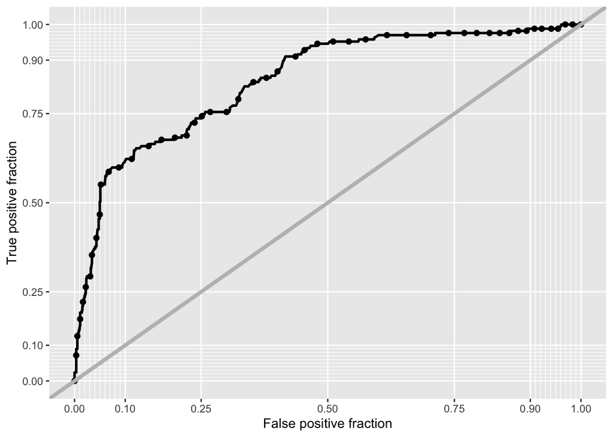

Our ROC curve visualizes a general diagnostic of our model’s performance. Based on our probability curve and confusion metrics, we decided that a threshold of 25% is the best probability level for our model to predict cells as flooded or not flooded.

## Cross Validation

Our cross validation plot shows similar accuracies across 100 tests, making it a promising model to introduce ‘out-of-sample’ data like DC.

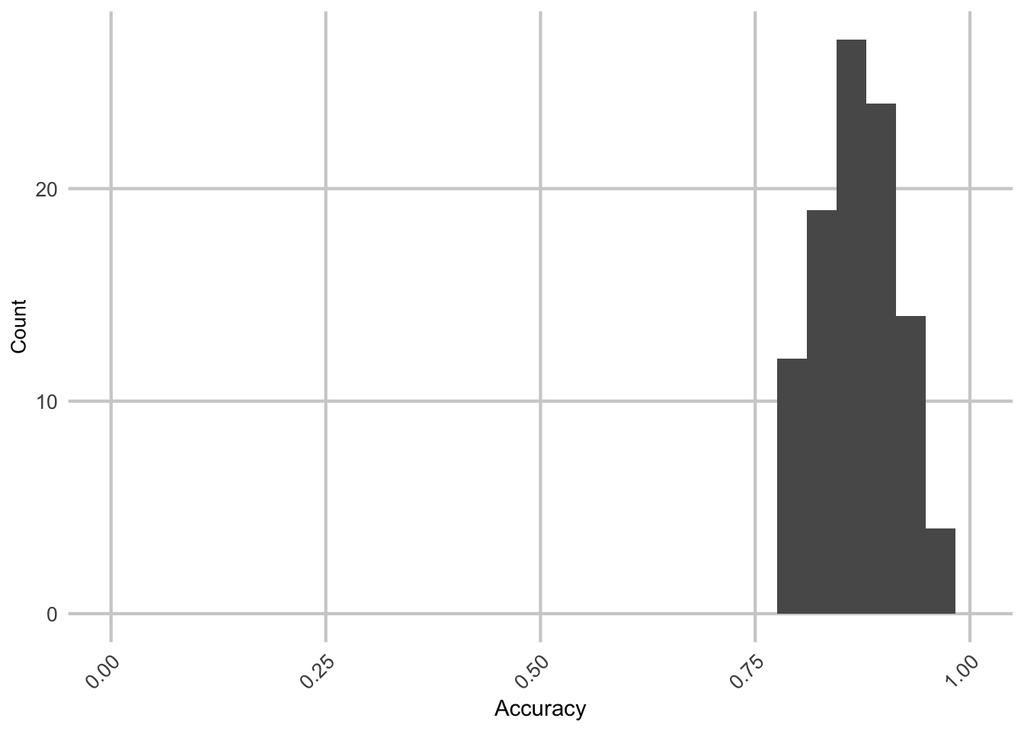

# Prediction Maps

## Confusion Metrics for Training Set

[figure not shown]

## Calgary Predictions

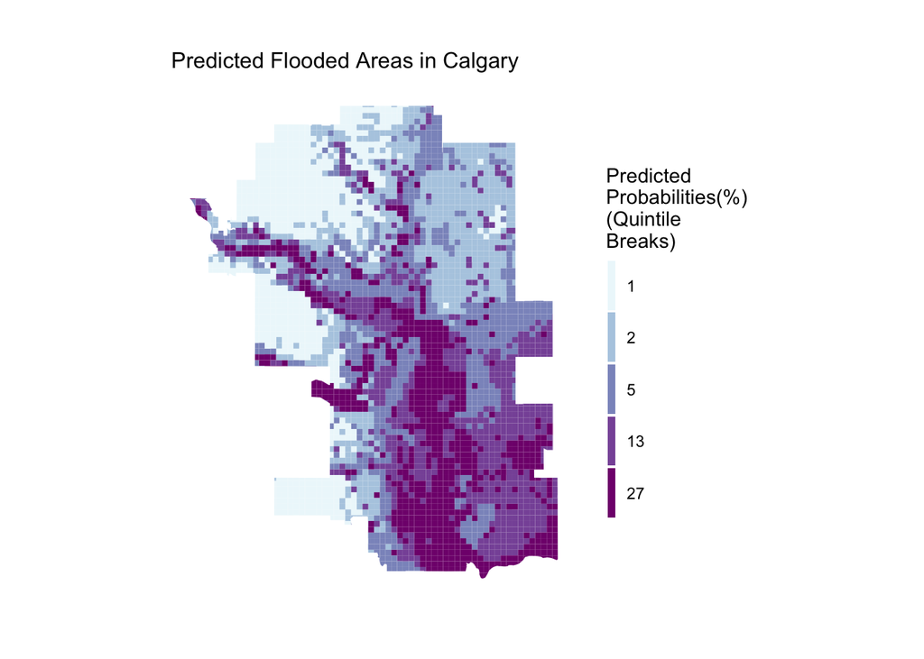

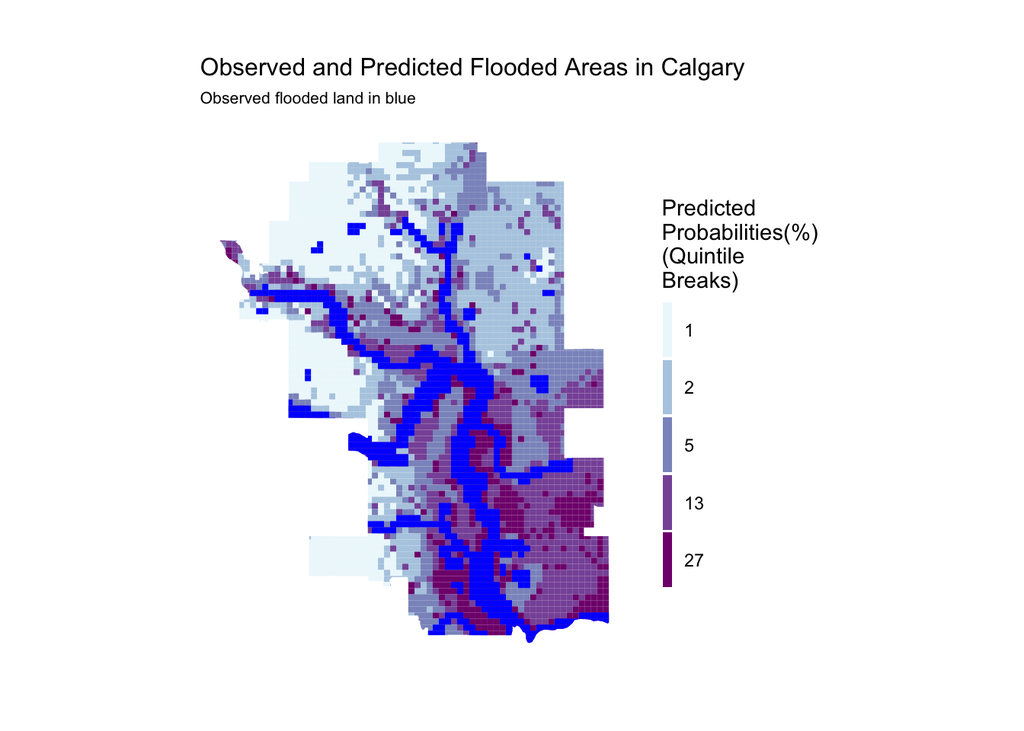

## DC Predictions

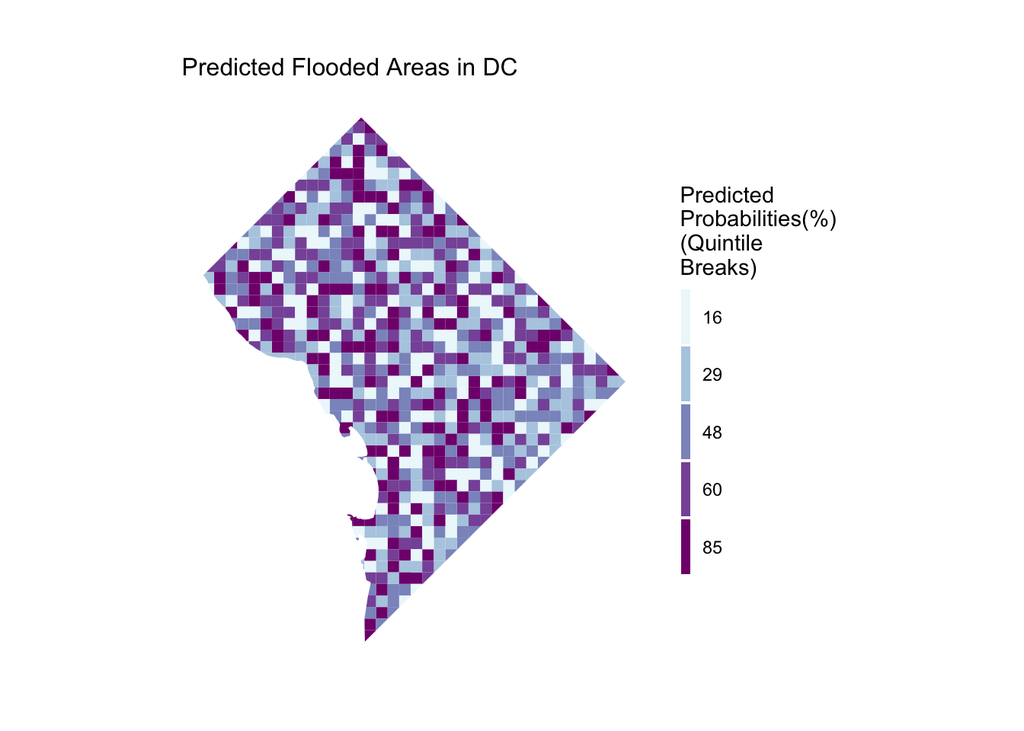